# White Wine Explorative Data Analysis

### Explorative Data Analysis

In this analysis, i am going to explore which chemical properties are influencing the quality of a white wine. I want know if there is a pattern of chemical properties in a good wine and a bad wine.

In Addition, i would like to know the distribution of chemical properties and see if there is are correlations between different properties. Some might be obvious like sugar and alcohol, but as i have no chemical background, it will be nice to see if there are other correlations.

# Univariate Plots Section

**1** First, i will take a look at how the data is structured and what variables are part of my dataset.

```
## 'data.frame':    4898 obs. of  13 variables:
##  $ X                   : int  1 2 3 4 5 6 7 8 9 10 ...
##  $ fixed.acidity       : num  7 6.3 8.1 7.2 7.2 8.1 6.2 7 6.3 8.1 ...
##  $ volatile.acidity    : num  0.27 0.3 0.28 0.23 0.23 0.28 0.32 0.27 0.3 0.22 ...
##  $ citric.acid         : num  0.36 0.34 0.4 0.32 0.32 0.4 0.16 0.36 0.34 0.43 ...
##  $ residual.sugar      : num  20.7 1.6 6.9 8.5 8.5 6.9 7 20.7 1.6 1.5 ...
##  $ chlorides           : num  0.045 0.049 0.05 0.058 0.058 0.05 0.045 0.045 0.049 0.044 ...
##  $ free.sulfur.dioxide : num  45 14 30 47 47 30 30 45 14 28 ...
##  $ total.sulfur.dioxide: num  170 132 97 186 186 97 136 170 132 129 ...
##  $ density             : num  1.001 0.994 0.995 0.996 0.996 ...
##  $ pH                  : num  3 3.3 3.26 3.19 3.19 3.26 3.18 3 3.3 3.22 ...
##  $ sulphates           : num  0.45 0.49 0.44 0.4 0.4 0.44 0.47 0.45 0.49 0.45 ...
##  $ alcohol             : num  8.8 9.5 10.1 9.9 9.9 10.1 9.6 8.8 9.5 11 ...
##  $ quality             : int  6 6 6 6 6 6 6 6 6 6 ...
```

As we can see, the quality of white wine is saved as integers. As stated in the guide, the quality is rated from 1 - 10 (1 being very bad and 10 very excellent), it might be a good idea to categorize these integers and store them in a additional variable. THis way we can see how many wines might be categorized as “good” or “bad”.

```
## [1] "Summary of our dataset variables"
```

```
##        X        fixed.acidity    volatile.acidity  citric.acid
##  Min.   :   1   Min.   : 3.800   Min.   :0.0800   Min.   :0.0000
##  1st Qu.:1225   1st Qu.: 6.300   1st Qu.:0.2100   1st Qu.:0.2700
##  Median :2450   Median : 6.800   Median :0.2600   Median :0.3200
##  Mean   :2450   Mean   : 6.855   Mean   :0.2782   Mean   :0.3342
##  3rd Qu.:3674   3rd Qu.: 7.300   3rd Qu.:0.3200   3rd Qu.:0.3900
##  Max.   :4898   Max.   :14.200   Max.   :1.1000   Max.   :1.6600
##  residual.sugar     chlorides       free.sulfur.dioxide
##  Min.   : 0.600   Min.   :0.00900   Min.   :  2.00
##  1st Qu.: 1.700   1st Qu.:0.03600   1st Qu.: 23.00
##  Median : 5.200   Median :0.04300   Median : 34.00
##  Mean   : 6.391   Mean   :0.04577   Mean   : 35.31
##  3rd Qu.: 9.900   3rd Qu.:0.05000   3rd Qu.: 46.00
##  Max.   :65.800   Max.   :0.34600   Max.   :289.00
##  total.sulfur.dioxide    density             pH          sulphates
##  Min.   :  9.0        Min.   :0.9871   Min.   :2.720   Min.   :0.2200
##  1st Qu.:108.0        1st Qu.:0.9917   1st Qu.:3.090   1st Qu.:0.4100
##  Median :134.0        Median :0.9937   Median :3.180   Median :0.4700
##  Mean   :138.4        Mean   :0.9940   Mean   :3.188   Mean   :0.4898
##  3rd Qu.:167.0        3rd Qu.:0.9961   3rd Qu.:3.280   3rd Qu.:0.5500
##  Max.   :440.0        Max.   :1.0390   Max.   :3.820   Max.   :1.0800
##     alcohol         quality
##  Min.   : 8.00   Min.   :3.000
##  1st Qu.: 9.50   1st Qu.:5.000
##  Median :10.40   Median :6.000
##  Mean   :10.51   Mean   :5.878
##  3rd Qu.:11.40   3rd Qu.:6.000
##  Max.   :14.20   Max.   :9.000
```

Taking a ook at the summary for quality, we can see that there are in fact no wines which have a quality of 10 and also none with the quality of 1 or 2. This will be important for our new variable.

```
## [1] "Dataset variables and their structure"
```

```
## 'data.frame':    4898 obs. of  13 variables:
##  $ X                   : int  1 2 3 4 5 6 7 8 9 10 ...
##  $ fixed.acidity       : num  7 6.3 8.1 7.2 7.2 8.1 6.2 7 6.3 8.1 ...
##  $ volatile.acidity    : num  0.27 0.3 0.28 0.23 0.23 0.28 0.32 0.27 0.3 0.22 ...
##  $ citric.acid         : num  0.36 0.34 0.4 0.32 0.32 0.4 0.16 0.36 0.34 0.43 ...
##  $ residual.sugar      : num  20.7 1.6 6.9 8.5 8.5 6.9 7 20.7 1.6 1.5 ...
##  $ chlorides           : num  0.045 0.049 0.05 0.058 0.058 0.05 0.045 0.045 0.049 0.044 ...
##  $ free.sulfur.dioxide : num  45 14 30 47 47 30 30 45 14 28 ...
##  $ total.sulfur.dioxide: num  170 132 97 186 186 97 136 170 132 129 ...
##  $ density             : num  1.001 0.994 0.995 0.996 0.996 ...
##  $ pH                  : num  3 3.3 3.26 3.19 3.19 3.26 3.18 3 3.3 3.22 ...
##  $ sulphates           : num  0.45 0.49 0.44 0.4 0.4 0.44 0.47 0.45 0.49 0.45 ...
##  $ alcohol             : num  8.8 9.5 10.1 9.9 9.9 10.1 9.6 8.8 9.5 11 ...
##  $ quality             : Ord.factor w/ 7 levels "3"<"4"<"5"<"6"<..: 4 4 4 4 4 4 4 4 4 4 ...
```

Let’s see if storing to a new variable worked.

```
## [1] "Dataset variables and their structure"
```

```
## 'data.frame':    4898 obs. of  14 variables:
##  $ X                   : int  1 2 3 4 5 6 7 8 9 10 ...
##  $ fixed.acidity       : num  7 6.3 8.1 7.2 7.2 8.1 6.2 7 6.3 8.1 ...
##  $ volatile.acidity    : num  0.27 0.3 0.28 0.23 0.23 0.28 0.32 0.27 0.3 0.22 ...
##  $ citric.acid         : num  0.36 0.34 0.4 0.32 0.32 0.4 0.16 0.36 0.34 0.43 ...
##  $ residual.sugar      : num  20.7 1.6 6.9 8.5 8.5 6.9 7 20.7 1.6 1.5 ...
##  $ chlorides           : num  0.045 0.049 0.05 0.058 0.058 0.05 0.045 0.045 0.049 0.044 ...
##  $ free.sulfur.dioxide : num  45 14 30 47 47 30 30 45 14 28 ...
##  $ total.sulfur.dioxide: num  170 132 97 186 186 97 136 170 132 129 ...
##  $ density             : num  1.001 0.994 0.995 0.996 0.996 ...
##  $ pH                  : num  3 3.3 3.26 3.19 3.19 3.26 3.18 3 3.3 3.22 ...
##  $ sulphates           : num  0.45 0.49 0.44 0.4 0.4 0.44 0.47 0.45 0.49 0.45 ...
##  $ alcohol             : num  8.8 9.5 10.1 9.9 9.9 10.1 9.6 8.8 9.5 11 ...
##  $ quality             : Ord.factor w/ 7 levels "3"<"4"<"5"<"6"<..: 4 4 4 4 4 4 4 4 4 4 ...
##  $ rating              : Ord.factor w/ 3 levels "bad"<"average"<..: 2 2 2 2 2 2 2 2 2 2 ...
```

We can see that we now have 3 levels of ordered factors for rating, which is what we wanted to achieve.

```
##        X        fixed.acidity    volatile.acidity  citric.acid
##  Min.   :   1   Min.   : 3.800   Min.   :0.0800   Min.   :0.0000
##  1st Qu.:1225   1st Qu.: 6.300   1st Qu.:0.2100   1st Qu.:0.2700
##  Median :2450   Median : 6.800   Median :0.2600   Median :0.3200
##  Mean   :2450   Mean   : 6.855   Mean   :0.2782   Mean   :0.3342
##  3rd Qu.:3674   3rd Qu.: 7.300   3rd Qu.:0.3200   3rd Qu.:0.3900
##  Max.   :4898   Max.   :14.200   Max.   :1.1000   Max.   :1.6600
##
##  residual.sugar     chlorides       free.sulfur.dioxide
##  Min.   : 0.600   Min.   :0.00900   Min.   :  2.00
##  1st Qu.: 1.700   1st Qu.:0.03600   1st Qu.: 23.00
##  Median : 5.200   Median :0.04300   Median : 34.00
##  Mean   : 6.391   Mean   :0.04577   Mean   : 35.31
##  3rd Qu.: 9.900   3rd Qu.:0.05000   3rd Qu.: 46.00
##  Max.   :65.800   Max.   :0.34600   Max.   :289.00
##
##  total.sulfur.dioxide    density             pH          sulphates
##  Min.   :  9.0        Min.   :0.9871   Min.   :2.720   Min.   :0.2200
##  1st Qu.:108.0        1st Qu.:0.9917   1st Qu.:3.090   1st Qu.:0.4100
##  Median :134.0        Median :0.9937   Median :3.180   Median :0.4700
##  Mean   :138.4        Mean   :0.9940   Mean   :3.188   Mean   :0.4898
##  3rd Qu.:167.0        3rd Qu.:0.9961   3rd Qu.:3.280   3rd Qu.:0.5500
##  Max.   :440.0        Max.   :1.0390   Max.   :3.820   Max.   :1.0800
##
##     alcohol      quality      rating
##  Min.   : 8.00   3:  20   bad    : 183
##  1st Qu.: 9.50   4: 163   average:3655
##  Median :10.40   5:1457   good   :1060
##  Mean   :10.51   6:2198
##  3rd Qu.:11.40   7: 880
##  Max.   :14.20   8: 175
##                  9:   5
```

Taking a look at our summary, we can now see that we have 183 wines which can be rated as bad, 3655 that have average quality and 1060 which are of good quality. In order to get a better feeling of the data, i am going to plot it.

### Quality and Rating

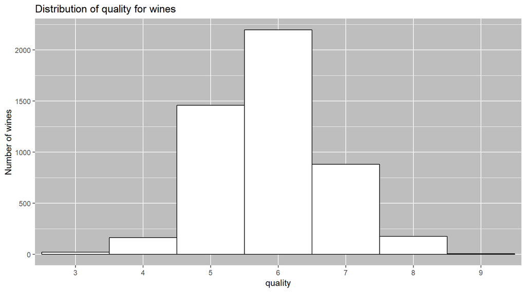

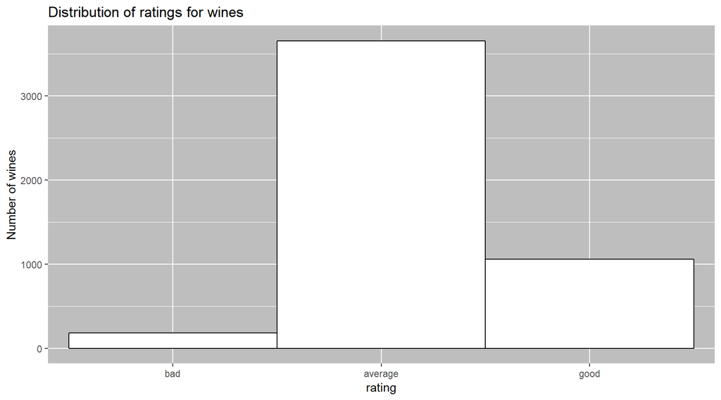

### Fixed acidity

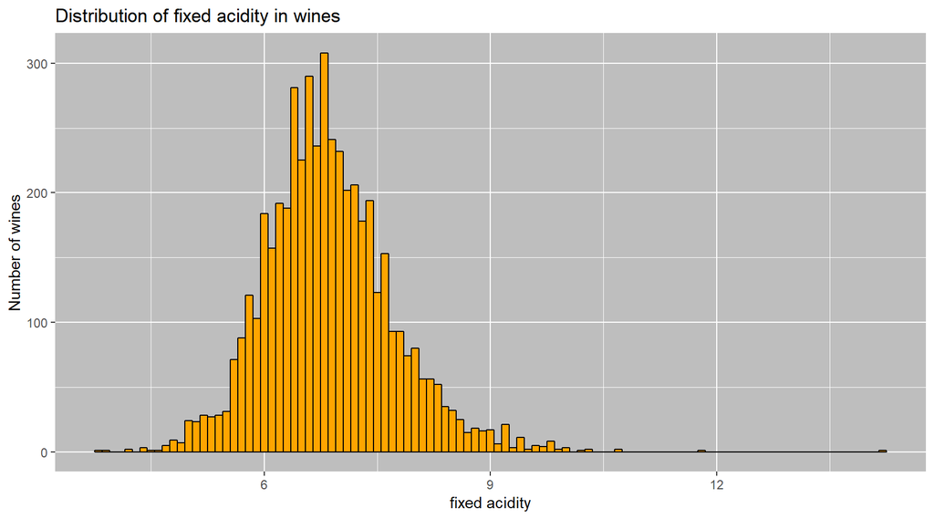

After plotting the fixed acidity, we can see that it is almost symetric, only very very slightly skewed to the right. There seem to be some outliers on the very right. There are no wines with no fixed acidity.

### Volatile acidity

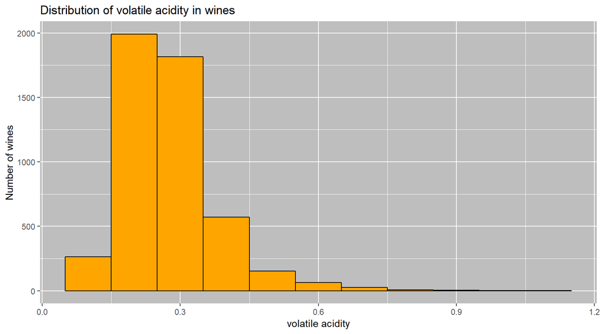

The plot is skewed to the right, with some outliers on the right hand side. Again, there are now wines with with volatile acidity equals 0.

### Citric Acid

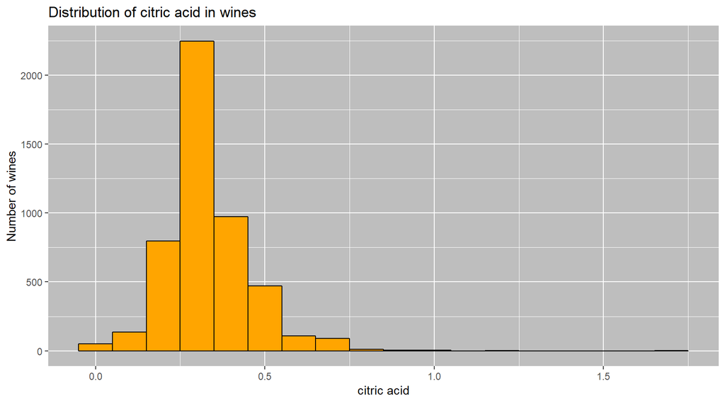

In contrast to the plots before, we now have wine with 0 citric acid. This might be due to mistakes in data collection, as wines (and white ones in particular) do have citric acid.

### Residual sugar

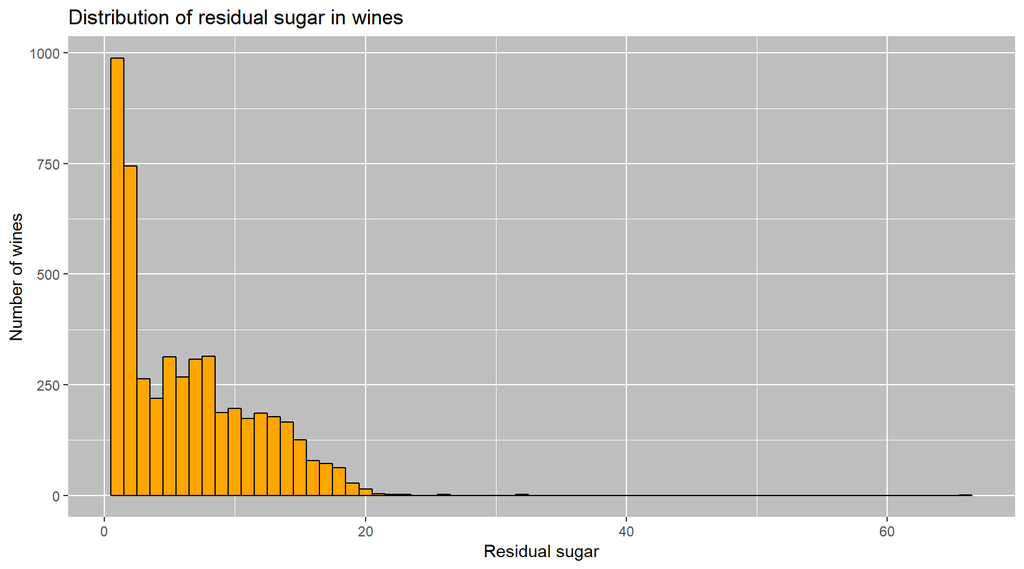

Taking a look at the residual sugar distribution, we can see that the plot is again skewed to the right. In order to have a better look at the outliers, we going to create a boxplot.

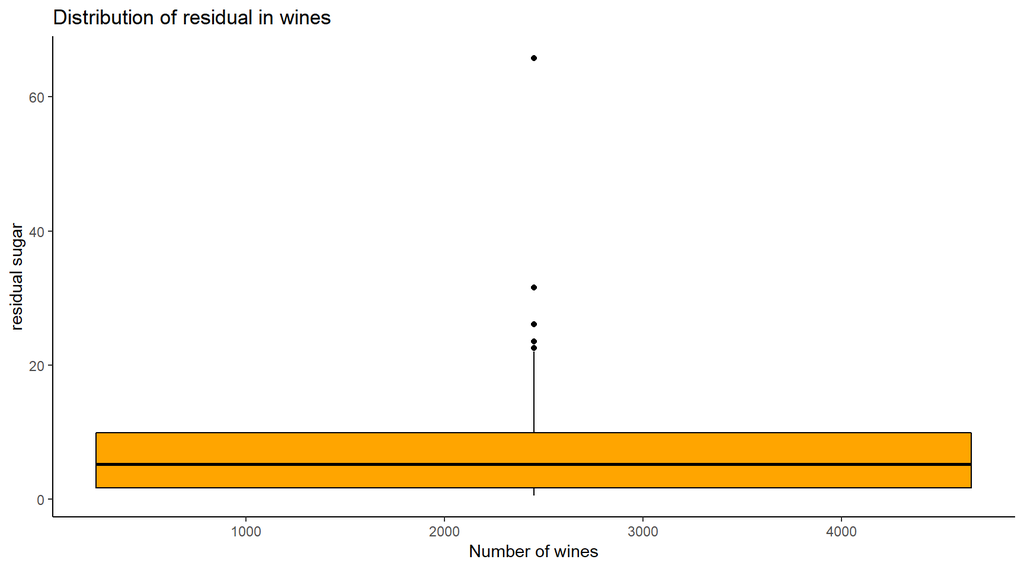

The median is at 5.2, while the max is over 60.

### Chlorides

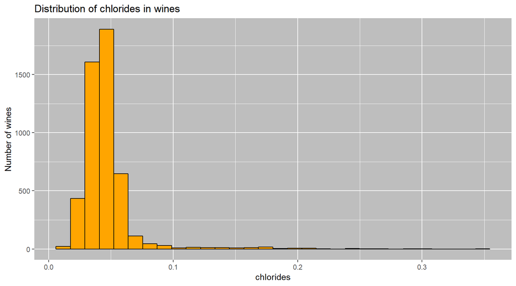

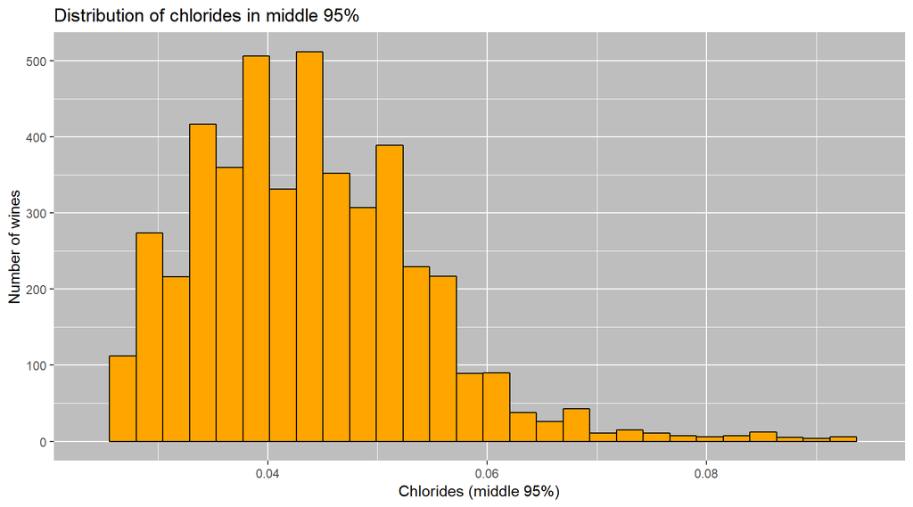

### Free sulfur dioxide

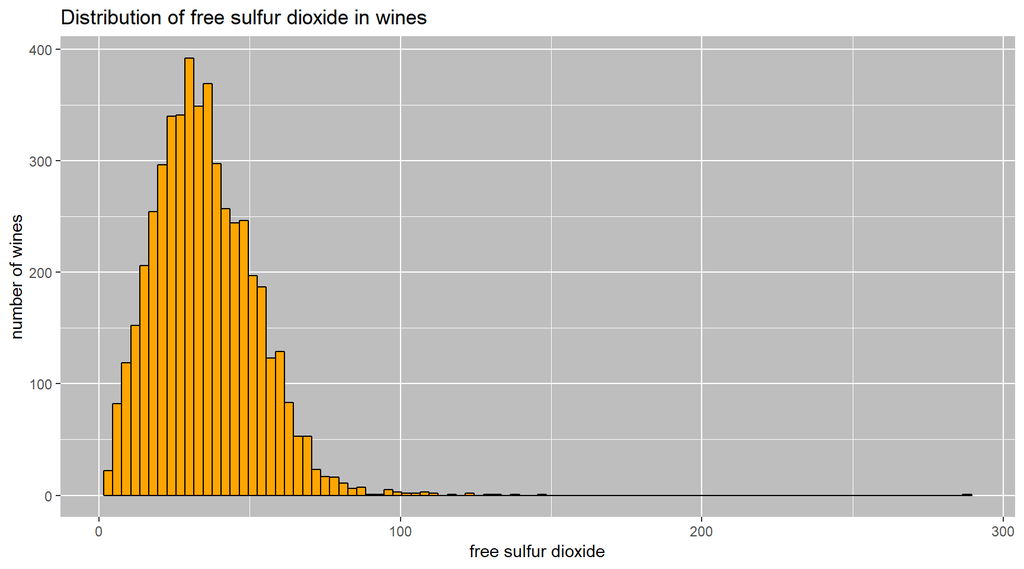

The distribution seems to be almost symetric, but is in fact slighty skewed to the right with very few outliers on the right hand side. Again, plotting a boxplot helps us to get a better look at the outliers and the median as well.

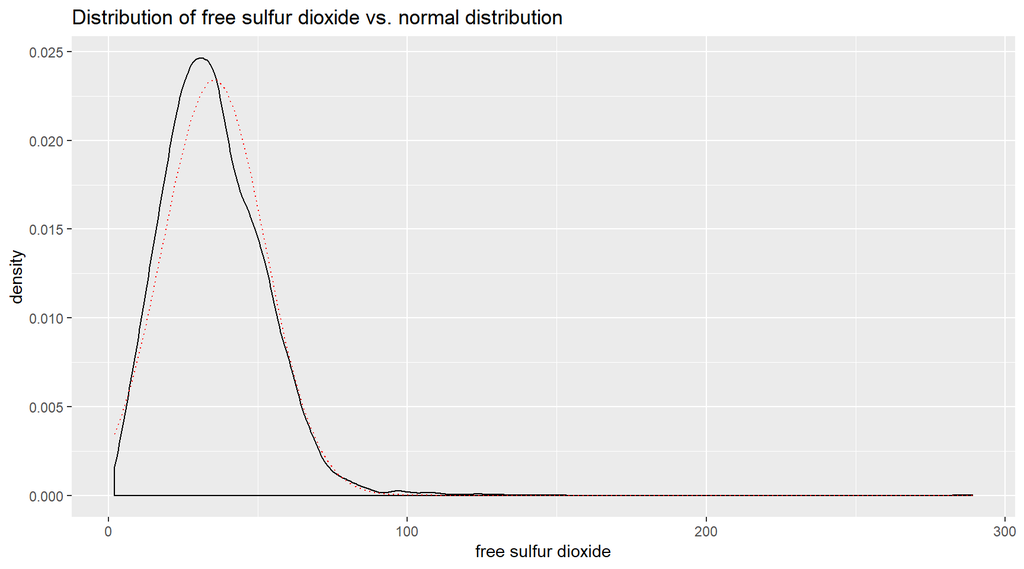

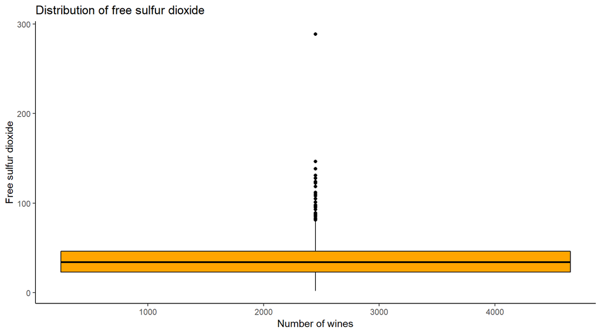

This plot cofirms what we saw before: We have very few outliers with a high value of free sulfur dioxide.

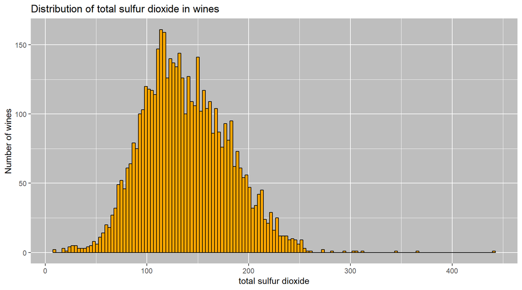

As we are looking at the total sufur dioxide, we get a similiar plot like we did before for free sulfur dioxides.

### Density

[figure not shown]

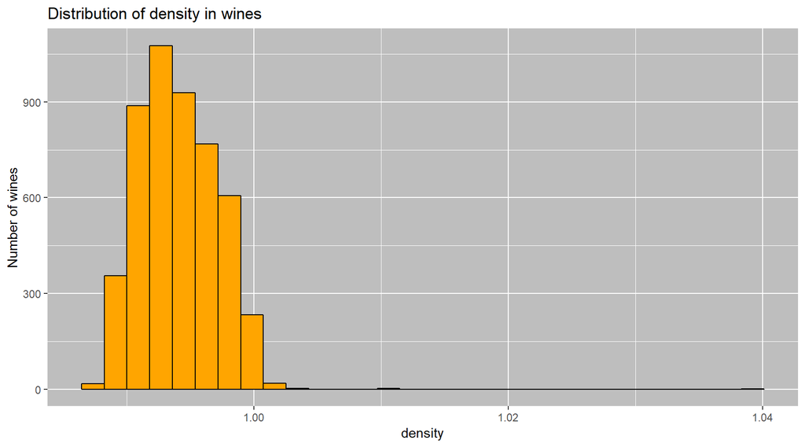

The distribution looks like a normal distribution, as the plot is almost symetrical. Let’s plot the boxplot as well.

Let’s check how close the distribution of the density is to a normal distribution.

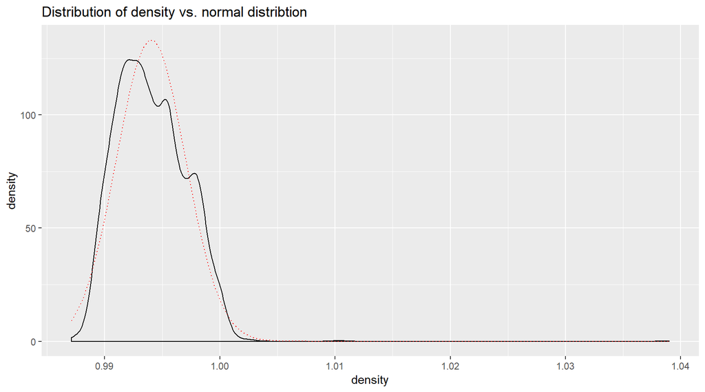

As we can see, the distribution is almost a normal one.

### pH

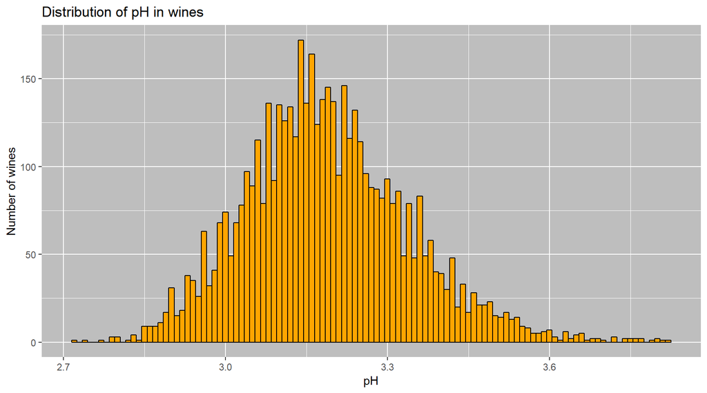

Just like the density, the pH values look normally distributed, as the plot is almost symetrical. This wil get even more obvious if we plot it in a line graph along with the normal distribution.

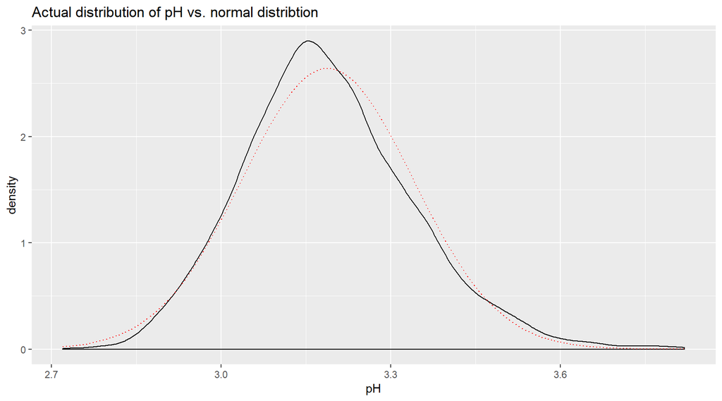

### Sulphates

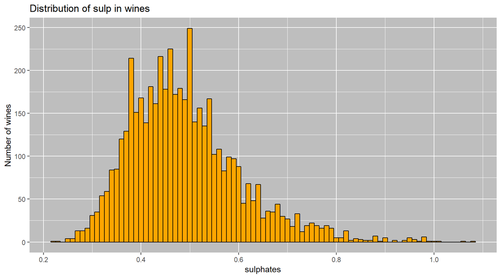

Taking a look at the distribution of sulphates, we can see that the plot is skewed to the right.

### Alcohol

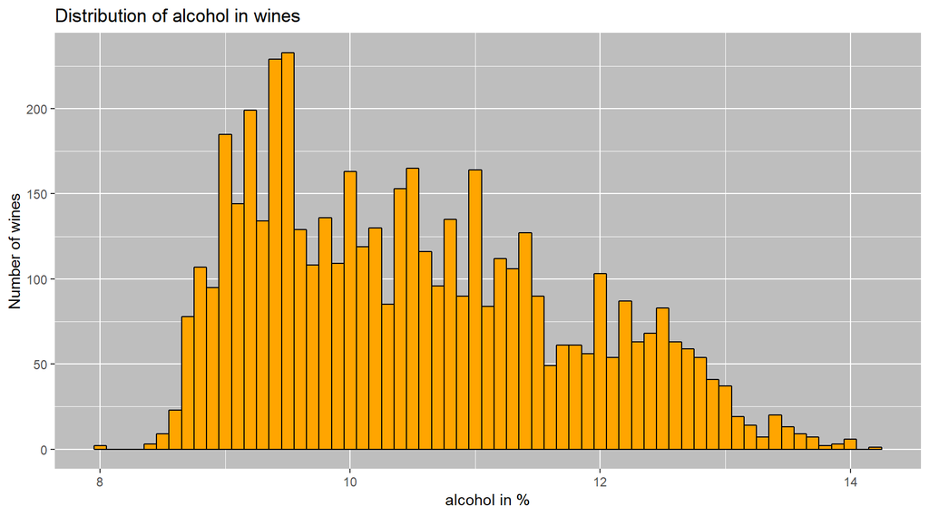

Again, the plot is skewed to the right.

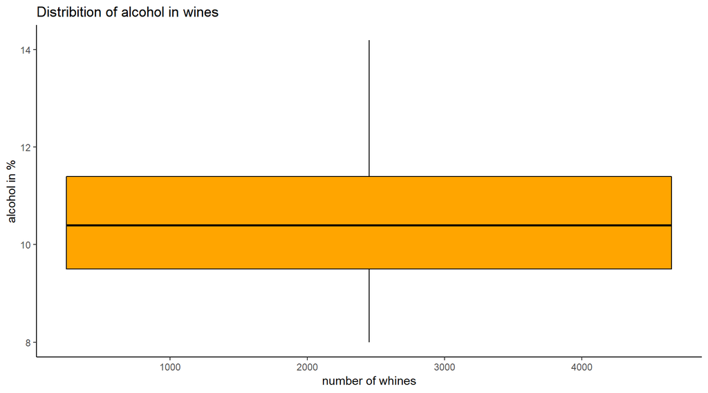

In contrast to other boxplots, we do not have any outliers which can bee seen in this graph. The mean is at 10.51.

# Univariate Analysis

### What is the structure of your dataset?

There are 4898 observations in our dataset, coming along with 13 variables. As we added one variale (rating), we now have 14.

Besides the quality variable, which has integer values, all other variables are of numerical type. There are variables, which represent chemical properties and there are some, that represent physical properties.

Additional observations:

Other observations:

There is no whine with a quality rating of 10. The meadian quality of white wines is 6, which would be an average wine in our rating. As we can see, most of the wines are rated as average, while only few wines are rated as bad, and quite some wines as good. The best rating is 9, the worst is 3.

Taking a look at the chemical and physical properties, we can see that some are almost normally distributed, but most of them are skewed to the right when being plotted.

### What is/are the main feature(s) of interest in your dataset?

Yes there is a main feature of interest in our dataset, which is the quality. I would like to know which properties correlate the most with the quality (good or bad) of a wine.

### What other features in the dataset do you think will help support your investigation into your feature(s) of interest?

I think that the following variables will help my investigation:

- alcohol and residual sugar. These variables should be correlating, as i know that the alcohol is determined, whether the grapes have had lots of sugar in it or not. So i think we might discover a negative correlation later, because if there is lots of residual sugar left, the value of alcohol should be lower. We will have a look into that.

Furthermore, i think that the acidity, namely fixed acidity, volatile acidity, citrix acid and pH might have its correlation on the quality, whether it is positive or negative.

### Did you create any new variables from existing variables in the dataset?

Yes. I created a new variable, called “rating”, which is based on the variable “quality”.

### Of the features you investigated, were there any unusual distributions? Did you perform any operations on the data to tidy, adjust, or change the form of the data? If so, why did you do this?

In addition, taking a look at the chlorides, i decided to only take a look at 95% of the data, in order to get rid of outliers.

# Bivariate Plots Section

As mentionend before, i would like to know which variables are correlating in which way with the quality. In addition, i will have a look at the correlation between different variables, like sugar and alcohol.

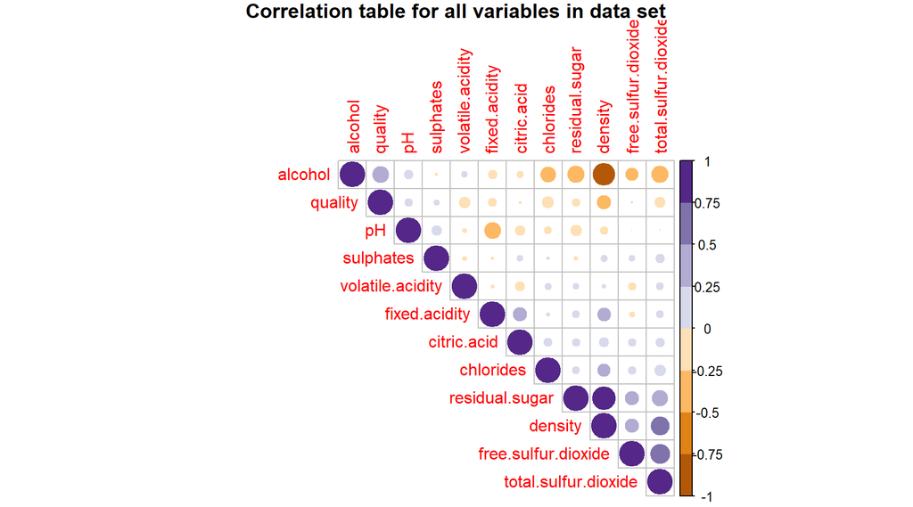

- the correlation coefficent for alcohol and residual sugar is -0,45. This is a negative one. It is not perfect negative, but residual sugar seems to have a significant (negative) influence on alcohol. And as alcohol has positive correlation on the quality, sugar indeed has quite an influence on the quality as well!

To put it in a nutshell: The variables which have to strongest, direct correlation with quality are alcohol, density (negative), chlorides (negative), total sulfur dioxid (negative) and fixed acidity (negative).

Additional insights:

- Alcohol has a negative correlation with density. This is true, as alcohol is known to have a lower density than water.

In order to see how the variables behave compared to the quality levels, we are going to plot some boxplots below.

### Quality vs. fixed acidity

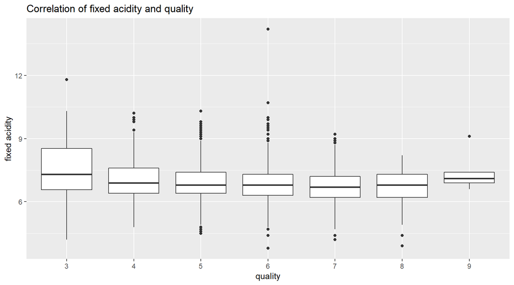

Let’s plot it again, this time for rating vs. fixed acidity. As we know that we do not have a fixed acidity lower that 3, we can limit the y axis.

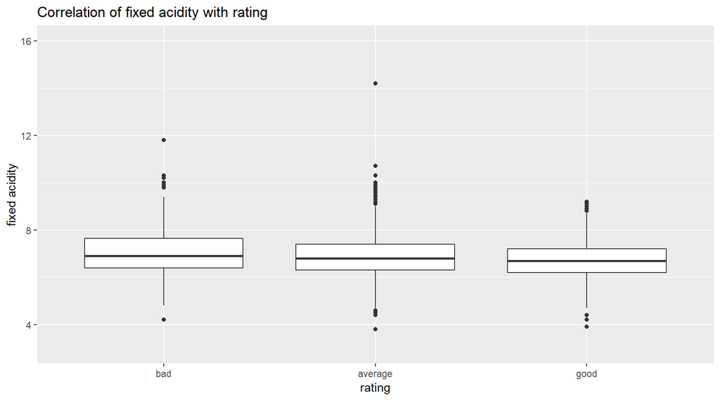

After plotting the fixed acidity with the quality and the rating, it get’s clearer that it seems to have close to no effect on quality and therefore the rating. Let’s do the same for the other variables. First, for obvious correlated variables like alcohol.

### Quality / Alcohol

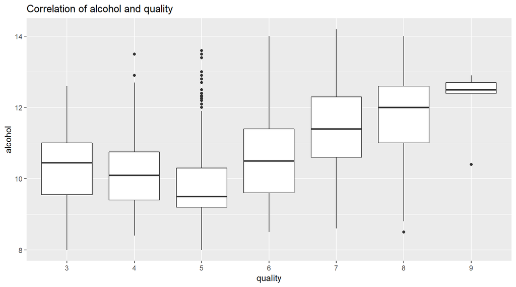

Taking a look at this graph, we can see that with a more alcohol, the quality seems to increase. But we can also see that we have quite some outliers, so i would guess that alcohol is not the sole property which has an inflcuence on quality, but that one has to make use of other properties in order to produce good whines, too. This picture even gets clearer if we plot the alcohol with rating. As we know that we have no alcohol value lower than 8 and higher than 14.20, can limit the y axis.

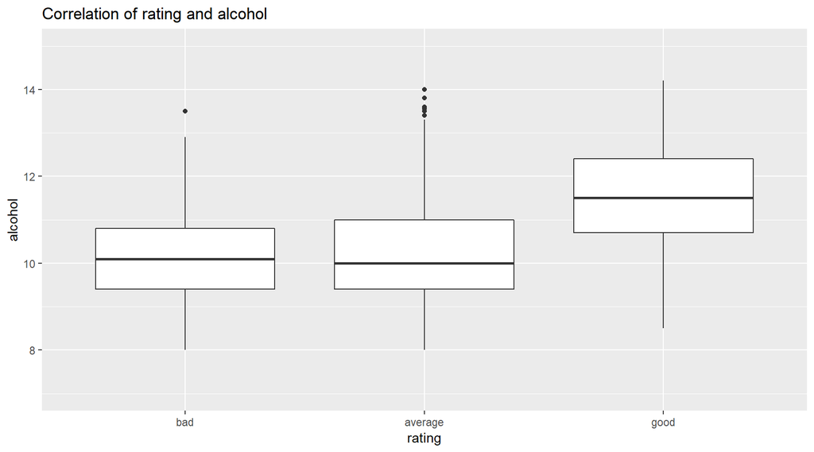

Taking a look at this graph, it shows us a similar picture like the graph above, only in a bit more summarised way.

Let’s see if we can find a value of how big the influence of alcohol is on the quality, mening to which amount it explains the so called variance. Therefore, we are going to use a linear regression model blow.

```
##
## Call:
## lm(formula = as.numeric(quality) ~ alcohol, data = white_wine)
##
## Residuals:
##     Min      1Q  Median      3Q     Max
## -3.5317 -0.5286  0.0012  0.4996  3.1579
##
## Coefficients:
##             Estimate Std. Error t value Pr(>|t|)
## (Intercept) 0.582009   0.098008   5.938 3.08e-09 ***
## alcohol     0.313469   0.009258  33.858  < 2e-16 ***
## ---
## Signif. codes:  0 '***' 0.001 '**' 0.01 '*' 0.05 '.' 0.1 ' ' 1
##
## Residual standard error: 0.7973 on 4896 degrees of freedom
## Multiple R-squared:  0.1897, Adjusted R-squared:  0.1896
## F-statistic:  1146 on 1 and 4896 DF,  p-value: < 2.2e-16
```

We have a R-squared value of 0.1897, meaning that alcohol explains about 19 % of the variablity in our data for quality for white wines. This seems to confirm that we have to look at other values as well and their influence on quality.

### Residual sugar / rating

Our correlation graph already showed us that residual sugar seems to have no direct influence on the quality. Let’s plot it, just for confirmation. As we know that our value rating is summarising our quality value, i will only plot rating from now on to have a better and simplified overview.

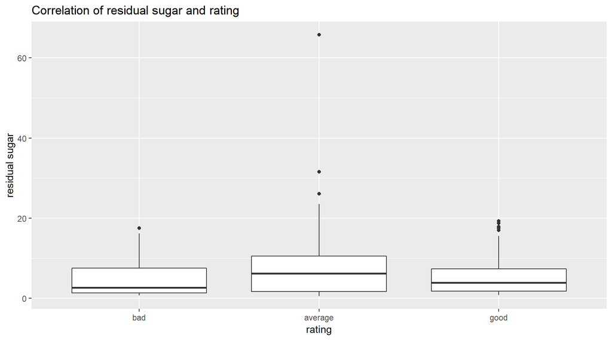

### Alcohol / Residual sugar

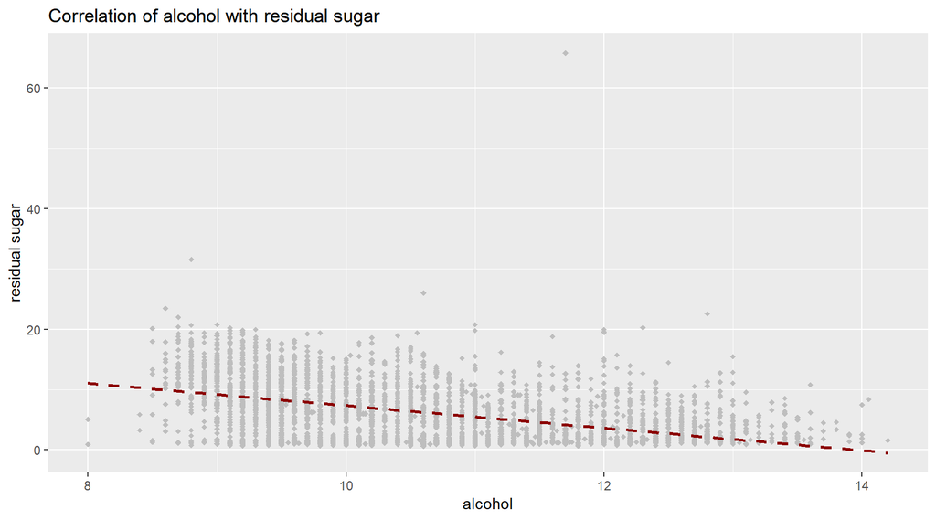

This plot confirms what that we have a negative correlation between alcohol and sugar. This makes sense due to the chemical process. The more sugar is left, the less alcohol is in and vice versa.

### Quality / volatile acidity.

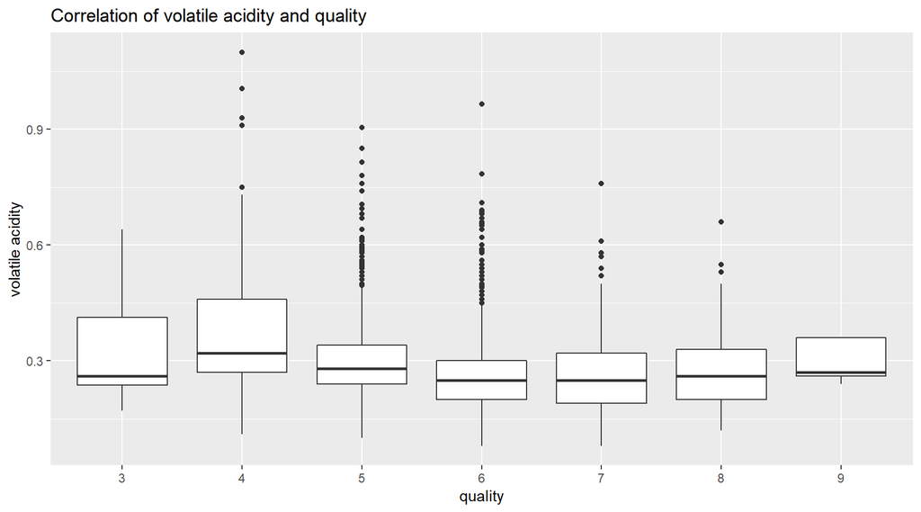

### Citric Acid / Quality

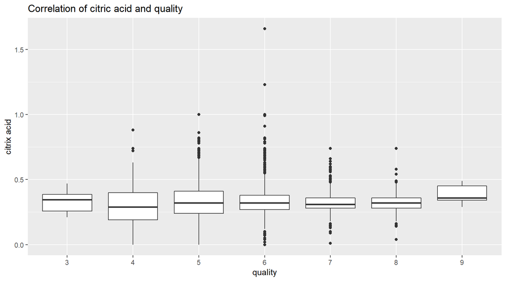

This boxplot shows, that the best wine quality seems to come with a higher value of citric acid. We can also see quite some outliers, expecialy for the quality which would be counted for the average rating range.

### Chlorides / Quality

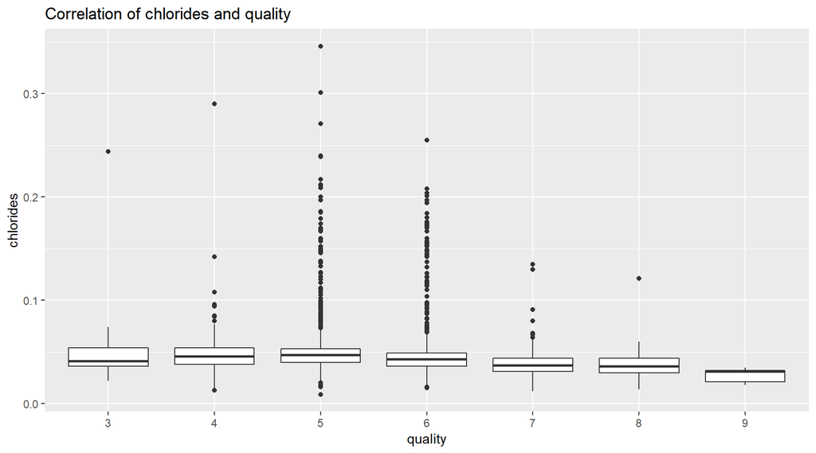

We already know that these two variables only do have a small correlation. But taking a look at this plot, though beeing correlated in a weak way, better quality seems to come with a lower value of chlorides.

### Free sulfur dioxide / Quality

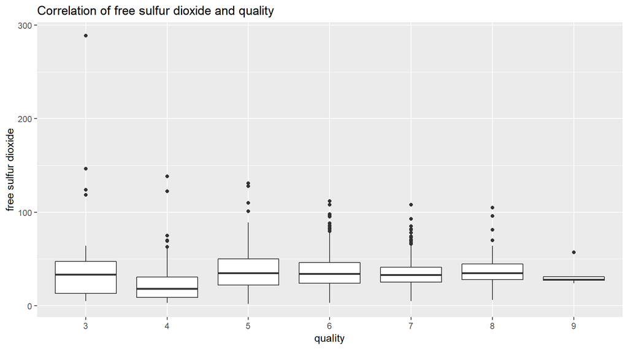

These two variables do have a weak correlation. What is interesting to see is that the range for a the top quality of 9 seems to be extremly close, while the range for bad quality whines with a quality value of 3 is the biggest. This nicely confirms that these to variables are in fact only correlated in a weak way.